# Solution 2

Hubert Rehrauer

25 9 2017

## Exploratory Data Analysis

Do an exploratory data analysis of a matrix of expression values. Load the data and display: * distributions: *boxplot*, *density*, *limma::plotDensities* * normalization: *limma::normalizeQuantiles* * clustering: *hclust* * heatmap: *heatmap.2* or *pheatmap* * correlation matrix: *cor* and *image* * reduced dimensionality representation: *cmdscale* and *prcomp*

## Data Import

```r
anno = read.table("SampleAnnotation.txt", as.is=TRUE, sep="\t", quote="",
                  row.names=1, header=TRUE)
x = read.table("expressiondata.txt", as.is=TRUE, sep="\t", quote="", row.names=1, header=TRUE, check.names = FALSE)
x = as.matrix(x)
```

## Define samples and colors and phenotype

```r
samples = rownames(anno)
colors = rainbow(nrow(anno))
isNorm = anno$TissueType == "norm"
isSick = anno$TissueType == "sick"
isAcute = anno$TissueType == "acute"
```

## Visualize distributions

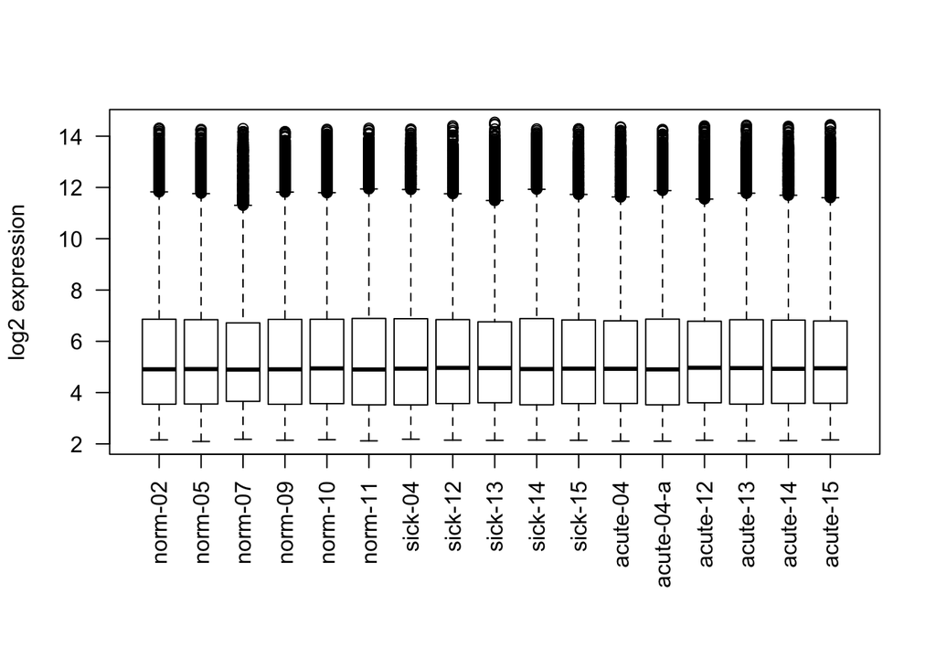

```r
par(mar=c(8, 4.1, 4.1, 2.1))
boxplot(log2(x), las=2, ylab="log2 expression")
```

## Density plot for one sample

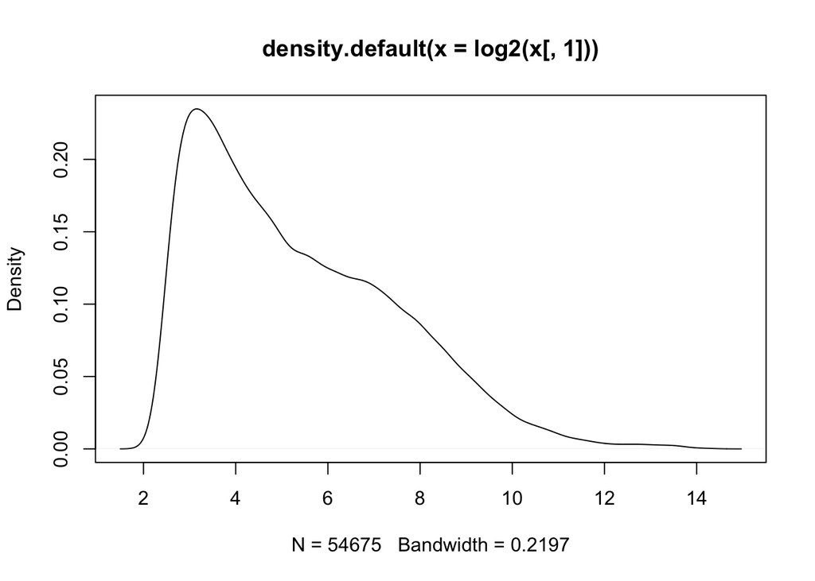

```r
plot(density(log2(x[,1])))
```

## limma’s function to plot densities

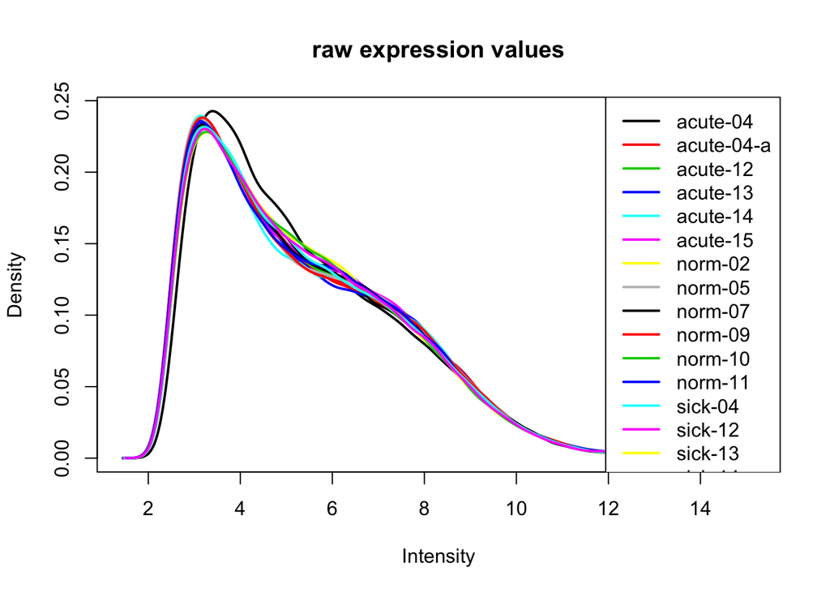

```r
library(limma)
plotDensities(log2(x), legend = "topright", main="raw expression values")
```

# Quantile normalization

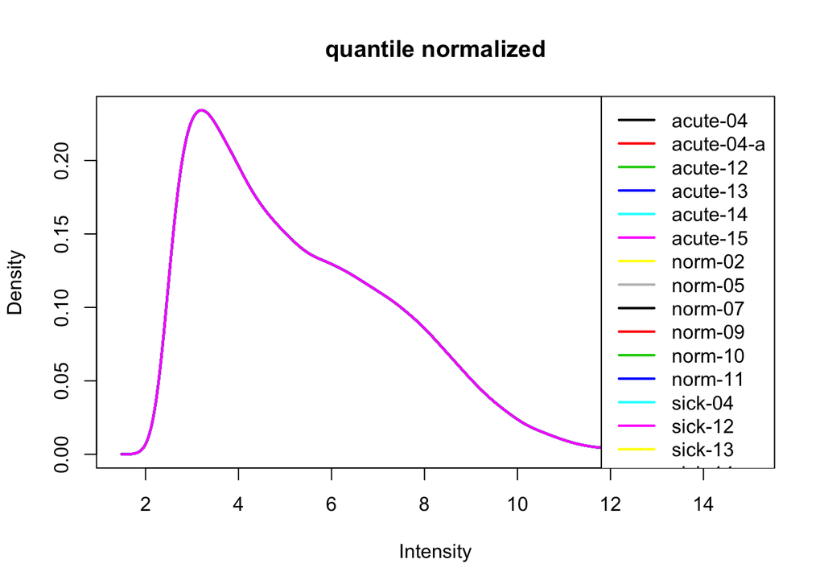

```r
require(limma)
xNorm = normalizeQuantiles(x)

plotDensities(log2(xNorm), legend = "topright", main="quantile normalized")
```

# Sample Clustering

The sample clustering shows the similarities of the expression patterns of the samples in a tree. In order to compute the similarities of the samples one can use all genes or only a subset of the genes. When using all genes where is the risk that the absent genes drive the clustering of the samples. This is because in many studies the absent genes make up the majority of the measured genes. But those genes have a low intensity that is strongly influenced by the background signal measured on each chip and not by real gene expression

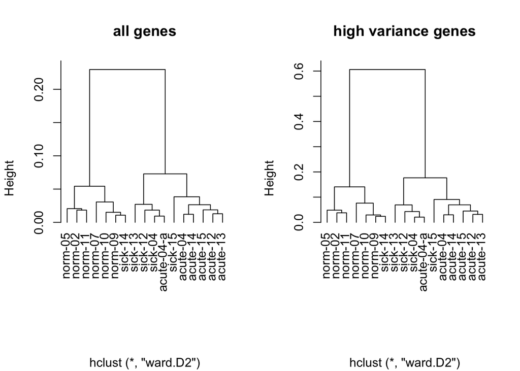

```r
x.sd = apply(x, 1, sd, na.rm=TRUE)
ord = order(x.sd, decreasing=TRUE)
highVarGenes = ord[1:500]
par(mfrow=c(1,2));
d = as.dist(1-cor(x));
c=hclust(d, method="ward.D2");
plot(c, hang=-0.1, main="all genes", xlab="")

d = as.dist(1-cor(x[highVarGenes, ]));
c=hclust(d, method="ward.D2");
plot(c, hang=-0.1, main="high variance genes", xlab="")
```

## Heatmaps of the expression data

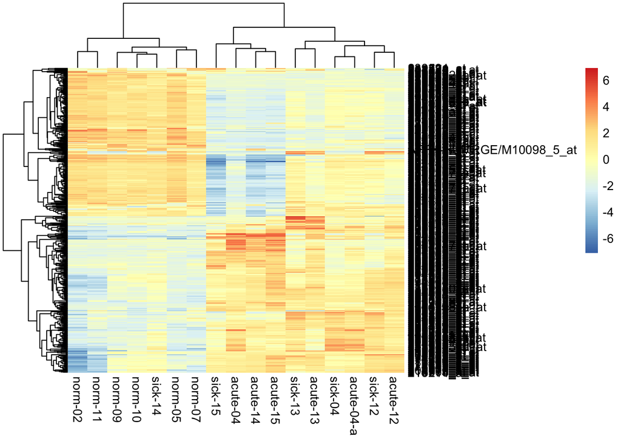

```r
library(pheatmap)
xNormLog2 = log2(xNorm)
diffLog2 = xNormLog2 - rowMeans(xNormLog2)
diffLog2.sd = apply(diffLog2, 1, sd, na.rm=TRUE)
highVarGenes = head(order(diffLog2.sd, decreasing = TRUE), 500)
res = pheatmap(diffLog2[highVarGenes, ])
```

# Checking the consistency of the replicates

```r
corrMatrix = cor(x)
signif(corrMatrix, digits=3)
```

```
##            norm-02 norm-05 norm-07 norm-09 norm-10 norm-11 sick-04 sick-12
## norm-02      1.000   0.980   0.962   0.965   0.956   0.982   0.907   0.878
## norm-05      0.980   1.000   0.963   0.977   0.974   0.980   0.937   0.923
## norm-07      0.962   0.963   1.000   0.984   0.968   0.967   0.940   0.922
## norm-09      0.965   0.977   0.984   1.000   0.985   0.969   0.955   0.943
## norm-10      0.956   0.974   0.968   0.985   1.000   0.973   0.956   0.949
## norm-11      0.982   0.980   0.967   0.969   0.973   1.000   0.924   0.899
## sick-04      0.907   0.937   0.940   0.955   0.956   0.924   1.000   0.983
## sick-12      0.878   0.923   0.922   0.943   0.949   0.899   0.983   1.000
## sick-13      0.879   0.915   0.925   0.938   0.940   0.898   0.977   0.975
## sick-14      0.953   0.979   0.972   0.989   0.987   0.966   0.964   0.959
## sick-15      0.857   0.883   0.928   0.931   0.940   0.893   0.940   0.944
## acute-04     0.890   0.915   0.934   0.951   0.949   0.906   0.977   0.970
## acute-04-a   0.901   0.933   0.944   0.958   0.963   0.924   0.991   0.984
## acute-12     0.870   0.908   0.926   0.945   0.950   0.895   0.966   0.983
## acute-13     0.858   0.891   0.923   0.934   0.935   0.882   0.962   0.970
## acute-14     0.876   0.904   0.929   0.947   0.948   0.898   0.962   0.969
## acute-15     0.833   0.871   0.892   0.911   0.919   0.857   0.940   0.962
##            sick-13 sick-14 sick-15 acute-04 acute-04-a acute-12 acute-13
## norm-02      0.879   0.953   0.857    0.890      0.901    0.870    0.858
## norm-05      0.915   0.979   0.883    0.915      0.933    0.908    0.891
## norm-07      0.925   0.972   0.928    0.934      0.944    0.926    0.923
## norm-09      0.938   0.989   0.931    0.951      0.958    0.945    0.934
## norm-10      0.940   0.987   0.940    0.949      0.963    0.950    0.935
## norm-11      0.898   0.966   0.893    0.906      0.924    0.895    0.882
## sick-04      0.977   0.964   0.940    0.977      0.991    0.966    0.962
## sick-12      0.975   0.959   0.944    0.970      0.984    0.983    0.970
## sick-13      1.000   0.948   0.939    0.966      0.977    0.970    0.973
## sick-14      0.948   1.000   0.936    0.957      0.970    0.958    0.945
## sick-15      0.939   0.936   1.000    0.967      0.962    0.971    0.969
## acute-04     0.966   0.957   0.967    1.000      0.984    0.980    0.979
## acute-04-a   0.977   0.970   0.962    0.984      1.000    0.981    0.975
## acute-12     0.970   0.958   0.971    0.980      0.981    1.000    0.987
## acute-13     0.973   0.945   0.969    0.979      0.975    0.987    1.000
## acute-14     0.953   0.958   0.975    0.988      0.977    0.987    0.982
## acute-15     0.949   0.930   0.960    0.970      0.957    0.985    0.981
##            acute-14 acute-15
## norm-02       0.876    0.833
## norm-05       0.904    0.871
## norm-07       0.929    0.892
## norm-09       0.947    0.911
## norm-10       0.948    0.919
## norm-11       0.898    0.857
## sick-04       0.962    0.940
## sick-12       0.969    0.962
## sick-13       0.953    0.949
## sick-14       0.958    0.930
## sick-15       0.975    0.960
## acute-04      0.988    0.970
## acute-04-a    0.977    0.957
## acute-12      0.987    0.985
## acute-13      0.982    0.981
## acute-14      1.000    0.983
## acute-15      0.983    1.000
```

Visualize the correlation matrix

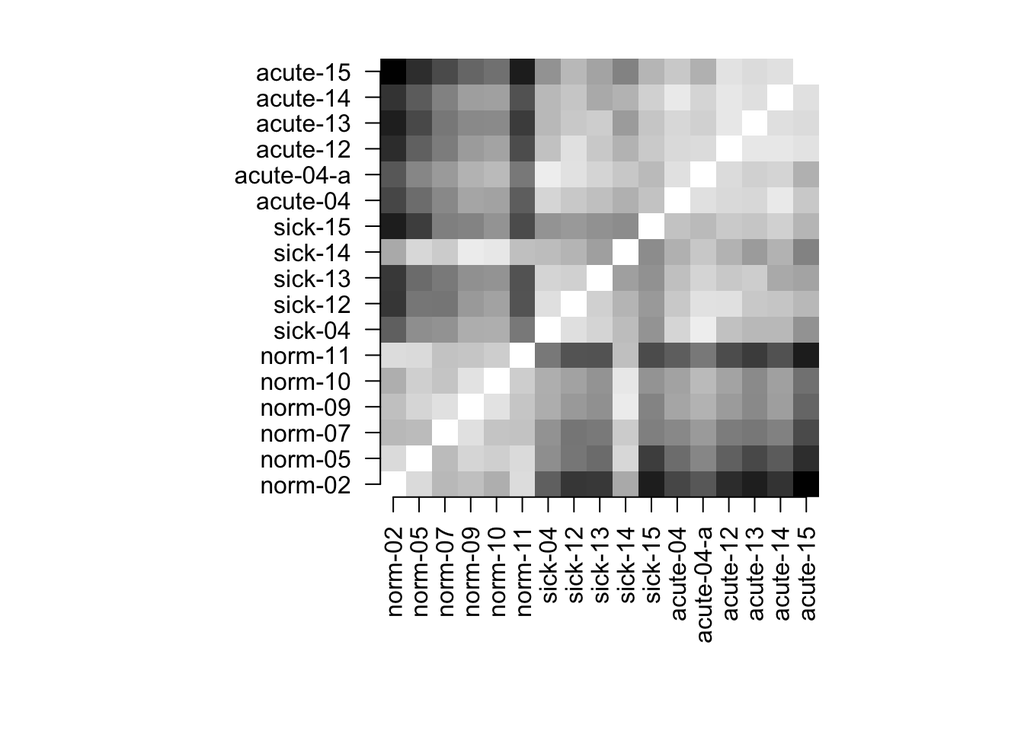

```r
par(mar=c(8,8,2,2), pty="s")
grayScale <- gray((1:256)/256)
image(corrMatrix, col=grayScale,  axes=FALSE)
axis(1, at=seq(from=0, to=1, length.out=length(samples)), labels=samples, las=2)
axis(2, at=seq(from=0, to=1, length.out=length(samples)), labels=samples, las=2)
```

The correlation plot shows

- normals show high correlation among each other
- the normal are very different from both sick and acute
- the sick and acute are rather similar
- `sick-14` rather looks like a normal sample
- `sick-15` has overall low correlation but rather looks like an “acute”
- `acute-04-a` which is a technical replicate of `acute-04` is more similar to `sick-04` than to `acute-04`.

# Multi-dimensional scaling and Principal component analysis

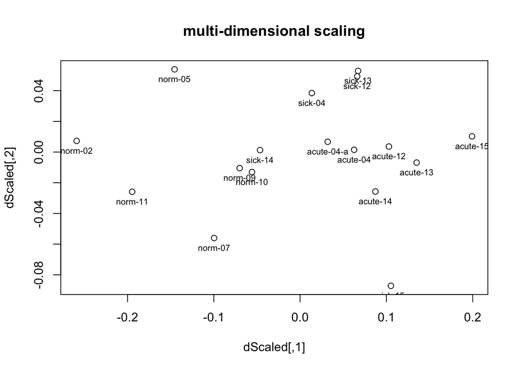

```r
dScaled <- cmdscale(d)
plot(dScaled, main="multi-dimensional scaling")
text(dScaled[ ,1],  dScaled[ ,2],labels =rownames(dScaled), pos=1, cex=0.7)
```

We are interested in the principle components for the samples that’s why we do transpose the matrix so that samples are in rows.

```r
pca <- prcomp(t(log2(x)))
summary(pca)
```

```
## Importance of components%s:
##                            PC1     PC2      PC3      PC4      PC5      PC6
## Standard deviation     62.9277 35.6186 22.93350 20.52474 19.71323 17.67572
## Proportion of Variance  0.4649  0.1489  0.06175  0.04946  0.04562  0.03668
## Cumulative Proportion   0.4649  0.6138  0.67558  0.72504  0.77066  0.80734
##                             PC7      PC8      PC9     PC10     PC11
## Standard deviation     15.74765 15.09706 14.05973 13.13650 12.66654
## Proportion of Variance  0.02911  0.02676  0.02321  0.02026  0.01884
## Cumulative Proportion   0.83645  0.86321  0.88642  0.90668  0.92551
##                            PC12     PC13     PC14     PC15    PC16
## Standard deviation     12.33402 11.98711 11.58887 10.51668 9.68211
## Proportion of Variance  0.01786  0.01687  0.01577  0.01298 0.01101
## Cumulative Proportion   0.94337  0.96024  0.97601  0.98899 1.00000
##                             PC17
## Standard deviation     1.689e-13
## Proportion of Variance 0.000e+00
## Cumulative Proportion  1.000e+00
```